# titanic_analysis

```python
import pandas as pd
import numpy as np
import seaborn as sns
import matplotlib.pyplot as plt

from sklearn.model_selection import train_test_split
from sklearn.linear_model import LogisticRegression
from sklearn.metrics import accuracy_score, confusion_matrix, classification_report
from sklearn.preprocessing import LabelEncoder, StandardScaler
```

### Step 1: Importing Libraries

We begin by importing all required Python libraries for data loading, analysis, visualization, and building the machine learning model.

```python
from google.colab import files
uploaded = files.upload()
```

Upload widget is only available when the cell has been executed in the current browser session. Please rerun this cell to enable.

```
Saving train.csv to train.csv
```

### Step 2: Upload the Titanic Dataset

We use Google Colab’s file upload feature to manually upload the `train.csv` file from our local system.

|  | PassengerId | Survived | Pclass | Name | Sex | Age | SibSp | Parch | Ticket | Fare | Cabin | Embarked |
| --- | --- | --- | --- | --- | --- | --- | --- | --- | --- | --- | --- | --- |
| 0 | 1 | 0 | 3 | Braund, Mr. Owen Harris | male | 22.0 | 1 | 0 | A/5 21171 | 7.2500 | NaN | S |
| 1 | 2 | 1 | 1 | Cumings, Mrs. John Bradley (Florence Briggs Th... | female | 38.0 | 1 | 0 | PC 17599 | 71.2833 | C85 | C |
| 2 | 3 | 1 | 3 | Heikkinen, Miss. Laina | female | 26.0 | 0 | 0 | STON/O2. 3101282 | 7.9250 | NaN | S |
| 3 | 4 | 1 | 1 | Futrelle, Mrs. Jacques Heath (Lily May Peel) | female | 35.0 | 1 | 0 | 113803 | 53.1000 | C123 | S |
| 4 | 5 | 0 | 3 | Allen, Mr. William Henry | male | 35.0 | 0 | 0 | 373450 | 8.0500 | NaN | S |

Distributions

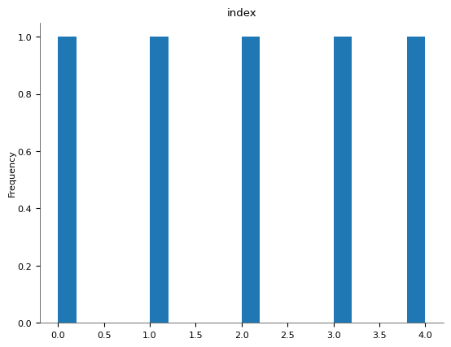

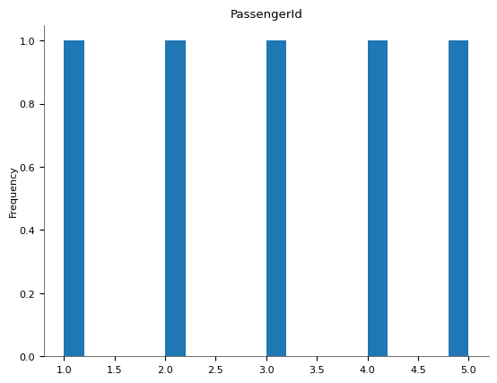

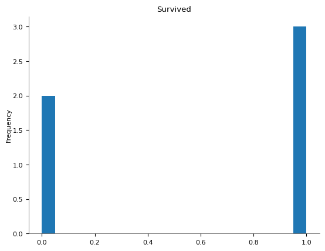

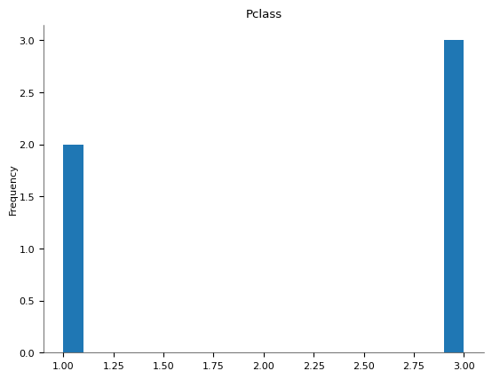

Categorical distributions

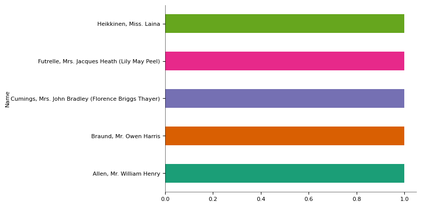

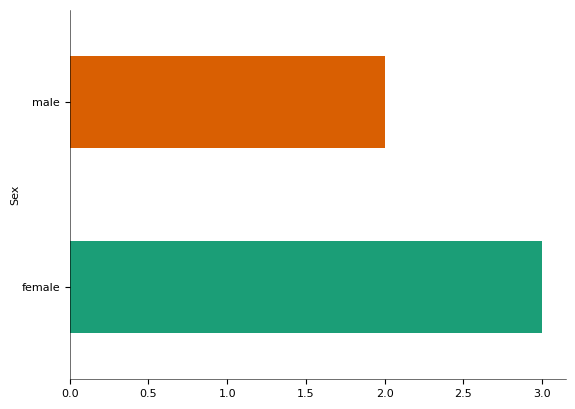

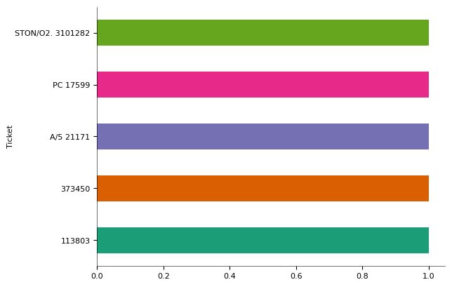

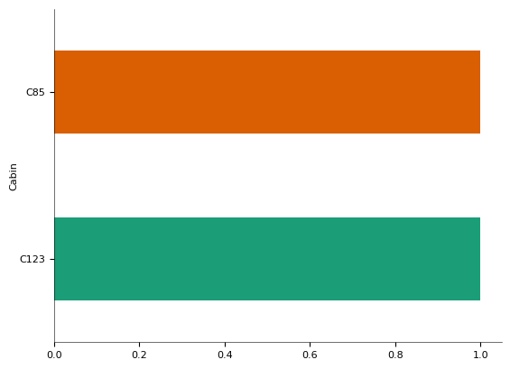

2-d distributions

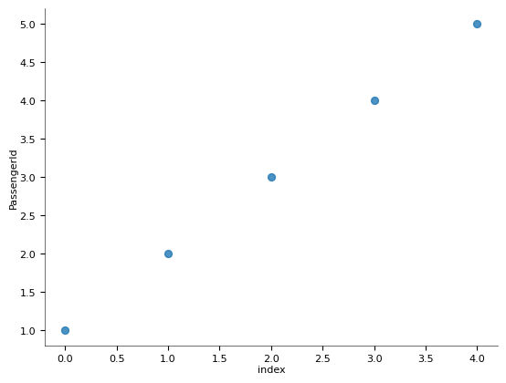

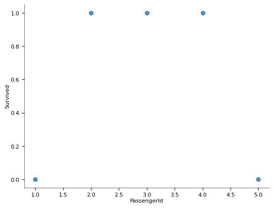

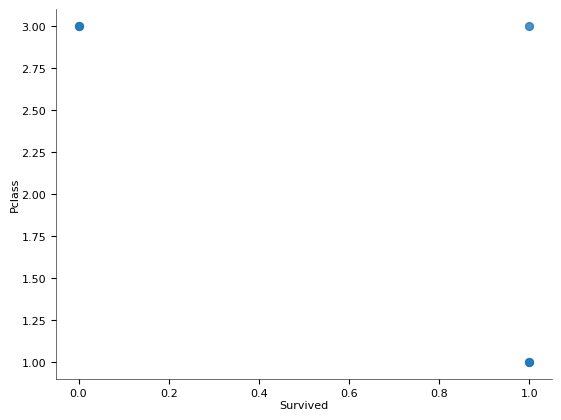

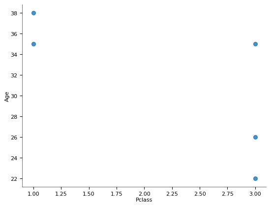

Time series

[16 more figures not shown]

```python
df = pd.read_csv("train.csv")
df.head()
```

### Step 3: Load the Dataset

We use pandas' `read_csv()` function to load the Titanic dataset into a DataFrame called `df` and display the first few rows using `df.head()`.

```python
df.info()
df.describe()
df.isnull().sum()
```

```
<class 'pandas.core.frame.DataFrame'>
RangeIndex: 891 entries, 0 to 890
Data columns (total 12 columns):
 #   Column       Non-Null Count  Dtype
---  ------       --------------  -----
 0   PassengerId  891 non-null    int64
 1   Survived     891 non-null    int64
 2   Pclass       891 non-null    int64
 3   Name         891 non-null    object
 4   Sex          891 non-null    object
 5   Age          714 non-null    float64
 6   SibSp        891 non-null    int64
 7   Parch        891 non-null    int64
 8   Ticket       891 non-null    object
 9   Fare         891 non-null    float64
 10  Cabin        204 non-null    object
 11  Embarked     889 non-null    object
dtypes: float64(2), int64(5), object(5)
memory usage: 83.7+ KB
```

|  | 0 |
| --- | --- |
| PassengerId | 0 |
| Survived | 0 |
| Pclass | 0 |
| Name | 0 |
| Sex | 0 |
| Age | 177 |
| SibSp | 0 |
| Parch | 0 |
| Ticket | 0 |
| Fare | 0 |
| Cabin | 687 |
| Embarked | 2 |

**dtype:** int64

### Step 4: Explore the Data

- `df.info()` gives us column names, data types, and non-null counts.
- `df.describe()` provides statistical summaries for numerical columns.
- `df.isnull().sum()` shows how many missing values exist in each column.

```python
print(df.columns.tolist())
```

[output not shown]

```python
df['Age'].fillna(df['Age'].mean(), inplace=True)
df['Embarked'].fillna(df['Embarked'].mode()[0], inplace=True)
```

## Handling missing values

Filling missing 'Age' with the mean age

Filling missing 'Embarked' with the most frequent value (mode)

```python
le = LabelEncoder()
df['Sex'] = le.fit_transform(df['Sex'])
df['Embarked'] = le.fit_transform(df['Embarked'])
```

## Encoding categorical features

Converting 'Sex' and 'Embarked' columns to numeric values using LabelEncoder

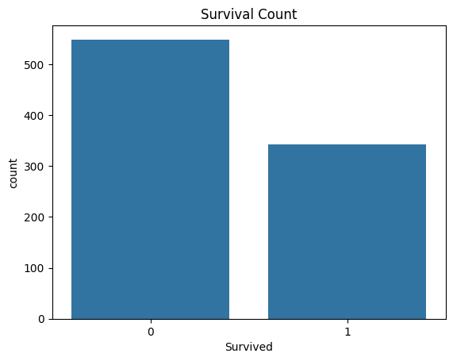

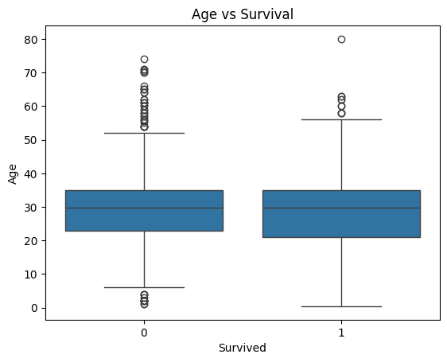

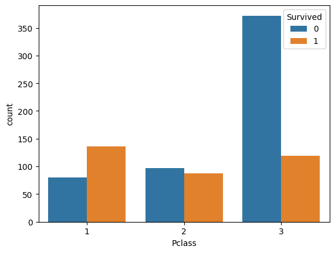

```python
sns.countplot(x='Survived', data=df)
plt.title('Survival Count')
plt.show()

sns.boxplot(x='Survived', y='Age', data=df)
plt.title('Age vs Survival')
plt.show()

sns.countplot(x='Pclass', hue='Survived', data=df)
```

## Data Visualization – Exploratory Data Analysis (EDA)

- `Survival Count`: Shows how many passengers survived vs didn’t.
- `Age vs Survival`: Gives idea of age distribution by survival.
- `Pclass vs Survival`: Highlights the impact of class on survival.

```python
X = df.drop('Survived', axis=1)
y = df['Survived']

scaler = StandardScaler()
X_scaled = scaler.fit_transform(X)

X_train, X_test, y_train, y_test = train_test_split(X_scaled, y, test_size=0.2, random_state=42)
```

## Feature Scaling and Train-Test Split

- Separates the features (X) and the target variable (y) for model training.
- Applies Standard Scaling to normalize the features — useful for algorithms that are sensitive to feature scales like logistic regression or SVM.
- Splits the dataset into training (80%) and testing (20%) sets to evaluate model performance effectively. A fixed random_state ensures reproducibility.

```python
model = LogisticRegression()
model.fit(X_train, y_train)
```

```
LogisticRegression()
```

## Model Training — Logistic Regression

A Logistic Regression model is initialized and trained using the training data (X_train, y_train). This algorithm is commonly used for binary classification tasks such as predicting survival (0 or 1) in the Titanic dataset.

```python
y_pred = model.predict(X_test)

print("Accuracy:", accuracy_score(y_test, y_pred))
print("Confusion Matrix:\n", confusion_matrix(y_test, y_pred))
print("Classification Report:\n", classification_report(y_test, y_pred))
```

[output not shown]

## Model Evaluation — Accuracy & Metrics

- y_pred: Predictions made by the model on unseen test data.
- accuracy_score: Measures how many predictions were correct.
- confusion_matrix: Shows counts of true/false positives/negatives.
- classification_report: Gives precision, recall, and F1-score per class.